# Netflix

## 1. Loading your friend's data into a dictionary

[figure not shown]

Netflix! What started in 1997 as a DVD rental service has since exploded into the largest entertainment/media company by [market capitalization](https://www.marketwatch.com/story/netflix-shares-close-up-8-for-yet-another-record-high-2020-07-10), boasting over 200 million subscribers as of [January 2021](https://www.cbsnews.com/news/netflix-tops-200-million-subscribers-but-faces-growing-challenge-from-disney-plus/).

Given the large number of movies and series available on the platform, it is a perfect opportunity to flex our data manipulation skills and dive into the entertainment industry. Our friend has also been brushing up on their Python skills and has taken a first crack at a CSV file containing Netflix data. For their first order of business, they have been performing some analyses, and they believe that the average duration of movies has been declining.

As evidence of this, they have provided us with the following information. For the years from 2011 to 2020, the average movie durations are 103, 101, 99, 100, 100, 95, 95, 96, 93, and 90, respectively.

```python
# Create the years and durations lists
years = [2011,2012,2013,2014,2015,2016,2017,2018,2019,2020]
durations = [103,101,99,100,100,95,95,96,93,90]

# Create a dictionary with the two lists
movie_dict = {"years": years, "durations": durations}

# Print the dictionary
movie_dict
```

```
{'years': [2011, 2012, 2013, 2014, 2015, 2016, 2017, 2018, 2019, 2020],
 'durations': [103, 101, 99, 100, 100, 95, 95, 96, 93, 90]}
```

## 2. Creating a DataFrame from a dictionary

```python
# Import pandas under its usual alias
import pandas as pd
# Create a DataFrame from the dictionary
durations_df = pd.DataFrame(movie_dict)

# Print the DataFrame
durations_df
```

|  | years | durations |
| --- | --- | --- |
| 0 | 2011 | 103 |
| 1 | 2012 | 101 |
| 2 | 2013 | 99 |
| 3 | 2014 | 100 |
| 4 | 2015 | 100 |
| 5 | 2016 | 95 |
| 6 | 2017 | 95 |
| 7 | 2018 | 96 |
| 8 | 2019 | 93 |
| 9 | 2020 | 90 |

## 3. A visual inspection of our data

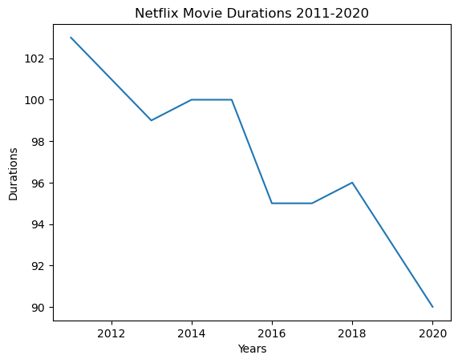

```python
# Import matplotlib.pyplot under its usual alias and create a figure
import matplotlib.pyplot as plt
fig = plt.figure()

# Draw a line plot of release_years and durations
plt.plot(durations_df["years"],durations_df["durations"])

# Create a title
plt.title("Netflix Movie Durations 2011-2020")
plt.xlabel("Years")
plt.ylabel("Durations")

# Show the plot
plt.show()
```

## 4. Loading the rest of the data from a CSV

```python
# Read in the CSV as a DataFrame
netflix_df = pd.read_csv("netflix_data.csv")

# Print the first five rows of the DataFrame
netflix_df.head()
```

|  | show_id | type | title | director | cast | country | date_added | release_year | duration | description | genre |
| --- | --- | --- | --- | --- | --- | --- | --- | --- | --- | --- | --- |
| 0 | s1 | TV Show | 3% | NaN | João Miguel, Bianca Comparato, Michel Gomes, R... | Brazil | August 14, 2020 | 2020 | 4 | In a future where the elite inhabit an island ... | International TV |
| 1 | s2 | Movie | 7:19 | Jorge Michel Grau | Demián Bichir, Héctor Bonilla, Oscar Serrano, ... | Mexico | December 23, 2016 | 2016 | 93 | After a devastating earthquake hits Mexico Cit... | Dramas |
| 2 | s3 | Movie | 23:59 | Gilbert Chan | Tedd Chan, Stella Chung, Henley Hii, Lawrence ... | Singapore | December 20, 2018 | 2011 | 78 | When an army recruit is found dead, his fellow... | Horror Movies |
| 3 | s4 | Movie | 9 | Shane Acker | Elijah Wood, John C. Reilly, Jennifer Connelly... | United States | November 16, 2017 | 2009 | 80 | In a postapocalyptic world, rag-doll robots hi... | Action |
| 4 | s5 | Movie | 21 | Robert Luketic | Jim Sturgess, Kevin Spacey, Kate Bosworth, Aar... | United States | January 1, 2020 | 2008 | 123 | A brilliant group of students become card-coun... | Dramas |

## 5. Filtering for movies!

```python
# Subset the DataFrame for type "Movie"
netflix_df_movies_only = netflix_df.loc[netflix_df['type'] == 'Movie']

# Select only the columns of interest
netflix_movies_col_subset = netflix_df_movies_only[['title', 'country', 'genre', 'release_year', 'duration']]


# Print the first five rows of the new DataFrame
netflix_movies_col_subset.head()
```

|  | title | country | genre | release_year | duration |
| --- | --- | --- | --- | --- | --- |
| 1 | 7:19 | Mexico | Dramas | 2016 | 93 |
| 2 | 23:59 | Singapore | Horror Movies | 2011 | 78 |
| 3 | 9 | United States | Action | 2009 | 80 |
| 4 | 21 | United States | Dramas | 2008 | 123 |
| 6 | 122 | Egypt | Horror Movies | 2019 | 95 |

## 6. Creating a scatter plot

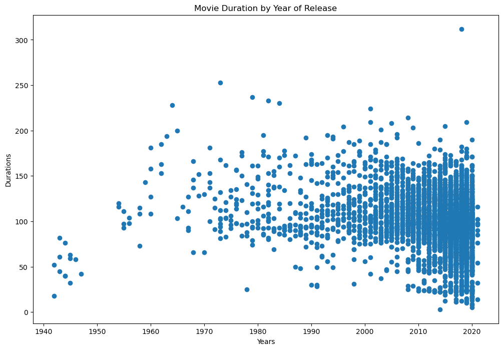

```python
# Create a figure and increase the figure size
fig = plt.figure(figsize=(12,8))

# Create a scatter plot of duration versus year
plt.scatter(netflix_movies_col_subset["release_year"],netflix_movies_col_subset["duration"])

# Create a title
plt.title("Movie Duration by Year of Release")
plt.xlabel("Years")
plt.ylabel("Durations")

# Show the plot
plt.show()
```

## 7. Digging deeper

```python
# Filter for durations shorter than 60 minutes
short_movies = netflix_movies_col_subset[netflix_movies_col_subset["duration"] < 60]

# Print the first 20 rows of short_movies
print(short_movies.head(20))
```

```
                                                 title         country  \
35                                           #Rucker50   United States
55                 100 Things to do Before High School   United States
67   13TH: A Conversation with Oprah Winfrey & Ava ...             NaN
101                                  3 Seconds Divorce          Canada
146                                     A 3 Minute Hug          Mexico
162  A Christmas Special: Miraculous: Tales of Lady...          France
171                         A Family Reunion Christmas   United States
177                    A Go! Go! Cory Carson Christmas   United States
178                    A Go! Go! Cory Carson Halloween             NaN
179                  A Go! Go! Cory Carson Summer Camp             NaN
181             A Grand Night In: The Story of Aardman  United Kingdom
200                            A Love Song for Latasha   United States
220                         A Russell Peters Christmas          Canada
233                              A StoryBots Christmas   United States
```

[output cut: 28 more lines]

## 8. Marking non-feature films

```python
# Define an empty list
colors = []

# Iterate over rows of netflix_movies_col_subset
for i,j in netflix_movies_col_subset.iterrows():
    if j["genre"] == "Children":
        colors.append("red")
    elif j["genre"] == "Documentaries":
        colors.append("blue")
    elif j["genre"] == "Stand-Up":
        colors.append("green")
    else:
        colors.append("black")

# Inspect the first 10 values in your list
print(colors[:10])
```

```
['black', 'black', 'black', 'black', 'black', 'black', 'black', 'black', 'black', 'blue']
```

## 9. Plotting with color!

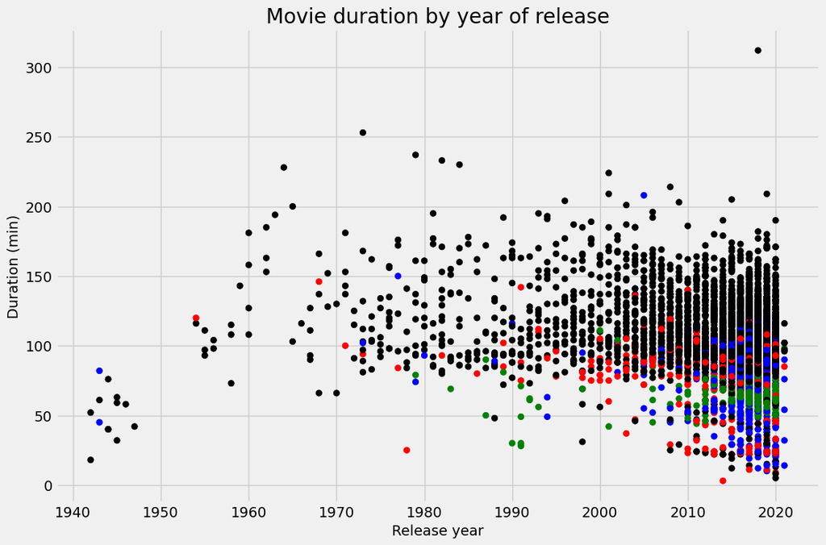

```python
# Set the figure style and initalize a new figure
plt.style.use('fivethirtyeight')
fig = plt.figure(figsize=(12,8))

# Create a scatter plot of duration versus release_year
plt.scatter(netflix_movies_col_subset["release_year"],netflix_movies_col_subset["duration"],c=colors)

# Create a title and axis labels
plt.title("Movie duration by year of release")
plt.xlabel("Release year")
plt.ylabel("Duration (min)")

# Show the plot
plt.show()
```

## 10. What next?

#### Are we certain that movies are getting shorter?

Henceforth, we can colclude that overall average time is getting shorter since the introduction of various genres of entertainment. So, we are yet uncertain that average movie time reduced because still average movie time is quite higher than the rest of the genres.